Ficha del establecimiento

# Escuela Básica Karelmapu

RBD **9614**San RamónEscuela o liceo

183estudiantes matriculadosCorte Agosto 2026

Mujeres44,8%82 est.

Hombres55,2%101 est.

Chilenos/as74,3%136 est.

Extranjeros/as25,7%47 est.

Actualizada al 05-10-2026

💻Ver ficha completaVersión para computador, con mapas y gráficos interactivos. Pesa varios MB: mejor ábrela con wifi.

🏛️Identificación

## Identificación del establecimiento

Los datos de contacto y las características básicas del establecimiento, tal como están registrados en el Ministerio de Educación. **Si algo está mal o falta, escríbenos** y lo corregimos en la próxima actualización.

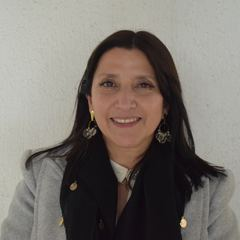

Director o directora

Elsa Paola Becerra Albanez

**Nombre**

Escuela Básica Karelmapu

**RBD**

9614

**Dirección**

Almirante Latorre 9299

**Comuna**

San Ramón

**Tipo**

Escuela o liceo

**Estado**

✅En funcionamiento

**Director/a**

Elsa Paola Becerra Albanez

**Correo**

escuelakarelmapu@slepsantarosa.cl

**Teléfono**

4058720

**Sitio web**

—

**Matrícula**

GRATUITO

**Sostenedor**

El sostenedor corresponde a una persona jurídica

**Orientación**

Orientación religiosa Católica

### Niveles que imparte

✓ 🧸 Educación Parvularia✓ 🎒 Enseñanza Básica Niños

### Vulnerabilidad del alumnado

Índice de vulnerabilidad (IVE)

95,4%

Lo calcula JUNAEB y sirve para asignar programas de apoyo.

0%100%

Este establecimientoPromedio de la comuna 86%

Prioritarios en Básica

87,3%

Estudiantes en 1ª, 2ª o 3ª prioridad.

**Un IVE más alto significa más necesidad de apoyo**, no peor calidad. Se usa para decidir a qué establecimientos llegan primero los programas de alimentación, salud y becas.

### Apoyos profesionales al aprendizaje

✓ 🧠 Psicólogo/a✓ 👩‍🏫 Profesor/a de educación especial✓ 🤝 Asistente social✓ 🗣️ Fonoaudiólogo/a📚 Reforzamiento🧩 Psicopedagogo/a🧭 Orientador/a🎓 Orientación vocacional➕ Otro

### Infraestructura y atención a la diversidad

✓ 📚 Biblioteca✓ 🌐 Computadores con internet✓ 📽️ Sala audiovisual✓ 🏟️ Cancha deportiva✓ ➕ Otra: PATIO TECHADO🔬 Laboratorio🏛️ Sala multiuso💻 Computadores🖥️ Sala de informática🤾 Gimnasio♿ Accesibilidad NEE

✓ 🧠 Discapacidad intelectual✓ 🧩 Trastorno del espectro autista✓ 💬 Trastornos de la comunicación✓ 🗣️ Trastorno específico del lenguaje✓ 🎯 Déficit atencional👁️ Discapacidad visual👂 Discapacidad auditiva🦽 Discapacidad motora📖 Dificultades de aprendizaje📊 Funcionamiento intelectual limítrofe

Las etiquetas con ✓ son las que el establecimiento declaró en el directorio oficial; las grises no están marcadas.

### Jornada Escolar Completa (JEC)

Cursos con jornada completa

8

Cursos sin jornada completa

2

**Ver curso por curso**

| Grado | Cursos | Jornada |
| --- | --- | --- |
| 1° Básico | 1 | ✅ Con JEC |
| 2° Básico | 1 | ✅ Con JEC |
| 3° Básico | 1 | ✅ Con JEC |
| 4° Básico | 1 | ✅ Con JEC |
| 5° Básico | 1 | ✅ Con JEC |
| 6° Básico | 1 | ✅ Con JEC |
| 7° Básico | 1 | ✅ Con JEC |
| 8° Básico | 1 | ✅ Con JEC |
| Kínder | 1 | — Sin JEC |
| Pre-kínder | 1 | — Sin JEC |

Con **Jornada Escolar Completa** los estudiantes tienen más horas de clases al día y almuerzan en el establecimiento.

### Certificación ambiental (SNCAE)

El establecimiento no tiene certificación del Sistema Nacional de Certificación Ambiental de Establecimientos Educacionales (SNCAE).

### Concentración de alumnado prioritario

Concentración 2026

64,9%

▼8,45 pts

Porcentaje de estudiantes prioritarios reconocidos por el Mineduc.

0%100%

Concentración del establecimiento

Concentración 2025

73,3%

Resolución exenta

2026

Observación del Ministerio: **Mantienen ACAP**.

La **concentración de prioritarios** define cuánta Subvención Escolar Preferencial (SEP) recibe el establecimiento. Sobre 60 % da acceso a la asignación por concentración.

### Requisitos para postular

✓ 🎂 Cumplir la edad mínima✓ 📄 Certificado de nacimiento✓ ✍️ Firmar el proyecto educativo✓ ⚖️ Firmar el reglamento de convivencia✓ 👥 Entrevista con apoderados📊 Certificado de notas📝 Informe de personalidad🏠 Ficha de protección social🧪 Test de intereses♿ Informe de necesidades educativas📋 Examen de ingreso🎲 Sorteo💍 Certificado de matrimonio⛪ Certificado de bautismo⛪ Certificado de matrimonio religioso💰 Pago de postulación➕ Otro

Desde el Sistema de Admisión Escolar, los establecimientos públicos **no pueden seleccionar** por rendimiento ni por antecedentes socioeconómicos. Estos son los antecedentes administrativos que el establecimiento declara pedir.

**Equipo del SLEP que acompaña al establecimiento**

**Asesor/a territorial**

RAÚL VASQUEZ DEL PINO

**Correo UTP**

utp.escuelakarelmapu@slepsantarosa.cl

**Correo Inspectoría**

inspectoria.escuelakarelmapu@slepsantarosa.cl

🏫Matrícula

## Matrícula y asistencia

Cuántos estudiantes tiene el establecimiento, quiénes son y cuántos días van efectivamente a clases. **La asistencia es el porcentaje de días que los estudiantes asistieron** sobre los días en que estuvieron matriculados.

Matrícula · Agosto 2026

183

▲1,7%

Variación desde el primer mes del año escolar.

1141.024

Este establecimientoPromedio del SLEP 333

Asistencia promedio

88,3%

Días asistidos sobre días matriculados.

73,8%93,1%

Este añoPromedio de años anteriores 86,5%

Cursos

10

Niveles

2

Matrícula regular

183

Estudiantes en la modalidad regular del establecimiento.

Matrícula no regular

0

Modalidades de adultos, reingreso o validación de estudios.

Matrícula mes a mes · 2026

Cuántos estudiantes había registrados al cierre de cada mes.

Asistencia mes a mes · 2026

Porcentaje de días asistidos sobre los días en que el estudiante estuvo matriculado.

Matrícula año a año

Matrícula del último mes de cada año escolar.

### Quiénes estudian acá

Por género

Hombres · 101Mujeres · 82

Por origen

Chilenos/as · 136Extranjeros/as · 47Nacionalizados/as · 0

Nacionalidades presentes

Número de estudiantes por país de nacimiento declarado.

🇨🇱 Chilena137

🇻🇪 Venezolana22

🌐 Otra7

❔ Sin información6

🇨🇴 Colombiana4

🇵🇪 Peruana4

Otros3

Pueblos originarios

Estudiantes que declaran pertenecer a un pueblo originario.

🌿 Mapuche5

### Por nivel de enseñanza

Matrícula por nivel

🧸 Educación Parvularia28

🎒 Enseñanza Básica Niños155

Asistencia por nivel

La escala va de 0 % a 100 %.

🧸 Educación Parvularia86,9%

🎒 Enseñanza Básica Niños88,6%

### Asistencia por grupo

Asistencia por género

Promedio ponderado por el número de estudiantes de cada grupo.

Hombres88,8%

Mujeres87,8%

Asistencia por origen

Chilenos/as86,5%

Extranjeros/as93,4%

Asistencia por nacionalidad

Solo los seis grupos con más estudiantes.

🇨🇱 Chilena86,9%

🇻🇪 Venezolana92,9%

🌐 Otra95,2%

❔ Sin información84,9%

🇨🇴 Colombiana96,4%

🇵🇪 Peruana92,9%

Asistencia por pueblo originario

🌿 Mapuche80,0%

**Ver el detalle curso por curso (10 cursos)**

| Curso | Matrícula | Asistencia % |
| --- | --- | --- |
| Pre-kínder A | 14 | 82,3 |
| Kínder A | 14 | 91,5 |
| 1° Básico A | 12 | 90,5 |
| 2° Básico A | 31 | 86,9 |
| 3° Básico A | 18 | 84,9 |
| 4° Básico A | 26 | 91,2 |
| 5° Básico A | 19 | 89,3 |
| 6° Básico A | 13 | 86,1 |
| 7° Básico A | 16 | 92 |
| 8° Básico A | 20 | 88,1 |

**Ver la matrícula año a año, con su variación**

| Periodo | Matrícula | Variación | Cambio |
| --- | --- | --- | --- |
| 2026 | 183 | −5,0 | −2,7% |
| 2025 | 188 | −8,0 | −4,1% |
| 2024 | 196 | −31,0 | −13,7% |
| 2023 | 227 | =0,0 | =0,0% |
| 2022 | 227 | −59,0 | −20,6% |
| 2019 | 286 | +7,0 | +2,5% |
| 2018 | 279 | +16,0 | +6,1% |
| 2017 | 263 | +1,0 | +0,4% |
| 2016 | 262 | — | — |

**Ver la asistencia año a año, con su variación**

| Periodo | Asistencia | Variación | Cambio |
| --- | --- | --- | --- |
| 2026 | 88,3% | −1,5 pts | −1,7% |
| 2025 | 89,8% | +3,6 pts | +4,2% |
| 2024 | 86,2% | +8,8 pts | +11,4% |
| 2023 | 77,4% | +2,3 pts | +3,1% |
| 2022 | 75,1% | −16,6 pts | −18,1% |
| 2019 | 91,7% | +2,0 pts | +2,2% |
| 2018 | 89,7% | −0,3 pts | −0,3% |
| 2017 | 90,0% | −1,6 pts | −1,7% |
| 2016 | 91,6% | — | — |

La matrícula se cuenta al cierre de cada mes, así que los cambios durante el año reflejan traslados y retiros. Corte usado: **Agosto 2026**.

🤝Vida escolar

## Vida escolar y comunidad

Qué actividades ofrece el establecimiento fuera de las clases, cómo se organiza con las familias y quiénes representan a la comunidad. **Las etiquetas con ✓ son las que el establecimiento declaró** en el directorio oficial del Ministerio; las grises no están marcadas.

### Talleres y actividades para estudiantes

✓ 🤝 Convivencia✓ 🚫 Prevención drogas✓ ❤️ Educación sexual✓ 🌱 Medio ambiente✓ 🌟 Vida sana✓ 🫂 Acción social✓ ➕ Otra: SALIDAS PEDAGOGICAS,HABILIDADES PARA LA VIDA, JUNA🧭 Orientación✝️ Pastoral

Actividades de formación: orientación, convivencia, prevención y vida sana.

✓ 🎭 Teatro✓ ✂️ Manualidades✓ 🎵 Música✓ 💻 Taller TIC📚 Literatura🩰 Danza o ballet🎨 Artes plásticas🎓 Preuniversitario➕ Otro

Talleres de arte, cultura y tecnología fuera del horario de clases.

✓ ⚽ Fútbol✓ 🥅 Baby fútbol✓ 🏐 Vóleibol✓ 🏀 Básquetbol✓ ♟️ Ajedrez🏃 Atletismo🏊 Natación🤸 Gimnasia🎾 Tenis🏓 Tenis de mesa➕ Otro

Disciplinas deportivas que ofrece el establecimiento.

### Trabajo con las familias

✓ 👪 Talleres de formación✓ 🎉 Actividades de integración📈 Perfeccionamiento➕ Otra

✓ 📒 Libreta de comunicaciones✓ 🌐 Web y redes sociales✓ 🗣️ Consejo escolar✓ 📄 Reuniones generales✓ 👥 Entrevistas individuales➕ Otro

Por dónde el establecimiento se comunica con apoderados y apoderadas.

### Organizaciones de la comunidad

**Centro de Padres**

Constituido

**Personalidad jurídica**

Vigente

**Última elección de directiva**

**Centro de Estudiantes**

Constituido

**Representante del sostenedor en el Consejo Escolar**

Bruno Cortés González

**Acompañamiento del Consejo Escolar**

Bruno Cortés González

Para contactar al centro de padres o al centro de estudiantes, escribe al establecimiento: sus datos están más arriba.

El **Consejo Escolar** es la instancia donde se juntan dirección, docentes, asistentes, apoderados y estudiantes para conversar sobre la marcha del establecimiento.

### Normativa y conectividad

**Uso de uniforme**

Uniforme propio del establecimiento

**Tipo de conexión**

Fibra óptica

**Velocidad de internet**

Sin información

🧭Gestión

## Instrumentos de gestión: PEI y PME

El **PEI** dice quién quiere ser el establecimiento: su misión, su visión y sus sellos. El **PME** dice qué va a hacer este año para lograrlo, con responsables y presupuesto. Son los dos documentos que ordenan el trabajo.

### Proyecto Educativo Institucional (PEI)

**Misión**

Entregar una educación pública y de calidad cuya institucionalidad garantiza y promueve espacios de participación a todos sus estamentos, siempre en el marco del respeto.Preparando estudiantes integrales, considerando sus necesidades educativas, sociales y culturales. con una formación académica consolidada en lo valórico, que les permita incorporarse a la educación media de manera exitosa, mejorando su calidad de vida y aportando a la comunidad en la que viven.

**Visión**

La comunidad educativa de la escuela Karelmapu busca dar oportunidades de una educación de calidad que garantice un desarrollo de aprendizajes significativos de todos los niños y niñas, a través de prácticas pedagógicas que promuevan el respeto, el cuidado del medio ambiente, la reflexión y el diálogo permanente, potenciando el talento, la creatividad y el espíritu crítico, que fortalezca las expectativas de las y los estudiantes respecto a su propio proyecto de vida.

### Énfasis declarados, en orden de prioridad

**1º**

Inclusivo

**2º**

Desarrollo integral

### Documentos oficiales

[📘Proyecto Educativo](https://wwwfs.mineduc.cl/Archivos/infoescuelas/documentos/9614/ProyectoEducativo9614.pdf)[⚖️Reglamento de Convivencia](https://wwwfs.mineduc.cl/Archivos/infoescuelas/documentos/9614/ReglamentodeConvivencia9614.pdf)[📊Reglamento de Evaluación](https://wwwfs.mineduc.cl/Archivos/infoescuelas/documentos/9614/ReglamentoDeEvaluacion9614.pdf)

### Plan de Mejoramiento Educativo (PME)

Acciones comprometidas

34

Inversión total del plan

$ 112.309.881

Dimensiones cubiertas

4

Acciones por dimensión

Las cuatro dimensiones del PME: gestión pedagógica, liderazgo, convivencia y recursos.

Gestión de Recursos12

Convivencia Escolar9

Gestión Pedagógica9

Liderazgo4

Quién lidera las acciones

Los cinco responsables con más acciones a cargo.

Director16

Jefe técnico6

Encargado de convivencia5

Sostenedor3

Equipo de gestión2

De dónde sale el financiamiento

Monto comprometido por fuente de recursos.

sep$ 111.340.464

pro retencion$ 969.417

**Ver las 34 acciones del plan**

| Acción | Dimensión | Responsable | Monto |
| --- | --- | --- | --- |
| Plan de Mejoramiento Lector. | Gestión Pedagógica | Jefe técnico | $ 0 |
| Acompañamiento al Aula. | Gestión Pedagógica | Jefe técnico | $ 0 |
| Estrategias para el desarrollo de la lectoescritura. | Gestión Pedagógica | Jefe técnico | $ 0 |
| Análisis de Resultados Evaluación DIA | Gestión Pedagógica | Jefe técnico | $ 0 |
| Implementar un huerto escolar en Pre - Básica. | Gestión Pedagógica | Equipo de gestión | $ 0 |
| Plan de Acompañamiento Decreto 67 | Gestión Pedagógica | Director | $ 18.257.436 |
| Articulación con redes externas para el fortalecimiento de capacidades en comunidades educativas | Gestión Pedagógica | Equipo Directivo | $ 0 |
| Servicio de Plataforma Educativa | Gestión Pedagógica | Jefe técnico | $ 1.262.412 |
| Plan de Transición Educativa (Decreto 373) | Gestión Pedagógica | Jefe técnico | $ 0 |
| Contratación de Profesionales para fortalecer la gestión de soporte para los procesos educativos | Liderazgo | Sostenedor | $ 8.469.154 |
| Garantizar la implementación efectiva del ciclo de mejora | Liderazgo | Director | $ 0 |
| Promoviendo el cumplimiento de metas institucionales | Liderazgo | Director | $ 0 |
| Contratación de Profesionales para el Apoyo en la Gestión Educativa (10% Administración Central) | Liderazgo | Sostenedor | $ 8.469.154 |
| Espacios de contención y apoyo emocional, social, educativo y afectivo. | Convivencia Escolar | Encargado de convivencia | $ 0 |
| Plan de retención y asistencia escolar | Convivencia Escolar | Encargado de convivencia | $ 0 |
| Asistencia y resguardo de las trayectorias educativas (Dupla psicosocial) | Convivencia Escolar | Director | $ 27.245.408 |
| Implementar una sala de psicomotricidad y contención socioemocional. | Convivencia Escolar | Sostenedor | $ 2.170.000 |
| Construyendo Comunidad | Convivencia Escolar | Encargado de convivencia | $ 399.207 |
| Fortalecimiento de competencias socioemocionales en la Comunidad Educativa | Convivencia Escolar | Encargado de convivencia | $ 46.748 |
| Servicio de transporte escolar para salidas pedagógicas y/o actividades extraescolares | Convivencia Escolar | Director | $ 2.000.000 |
| Reconocimiento a estudiantes | Convivencia Escolar | Encargado de convivencia | $ 395.556 |
| Servicio de traslado para salidas pedagógicas y/o actividades extraescolares | Convivencia Escolar | Equipo de gestión | $ 2.000.000 |
| Optimización y Registro Integral de Recursos y Personal. | Gestión de Recursos | Inspector General | $ 0 |
| Habilitación de sala de computación para el desarrollo de habilidades digitales. | Gestión de Recursos | Director | $ 1.357.743 |
| Servicio de equipos multicopiadores para el apoyo pedagógico. | Gestión de Recursos | Director | $ 2.686.650 |
| Adquisición de material escolar para el apoyo al aprendizaje. | Gestión de Recursos | Director | $ 0 |
| Contratación de docentes y/o asistentes de la educación para apoyo pedagógico. | Gestión de Recursos | Director | $ 0 |
| Contratación de Docentes y/o Asistentes de la Educación para Apoyo Pedagógico | Gestión de Recursos | Director | $ 31.761.124 |
| Servicio de Impresión para el Apoyo Pedagógico | Gestión de Recursos | Director | $ 2.417.989 |
| Compra de Material Escolar para el Apoyo al Aprendizaje | Gestión de Recursos | Director | $ 1.107.432 |
| Implementación de una Sala Sensorial para la Inclusión Educativa | Gestión de Recursos | Director | $ 799.354 |
| Implementación de Recursos Digitales para el Aprendizaje Escolar | Gestión de Recursos | Director | $ 163.710 |
| Adquisición de Kits Sensoriales para el Desarrollo Integral de Estudiantes. | Gestión de Recursos | Director | $ 780.000 |
| Implementación de un Espacio Lúdico-Didáctico en la Biblioteca Escolar | Gestión de Recursos | Director | $ 520.804 |

**Ver plazos y estado de ejecución de cada acción**

| Acción | Inicio | Término | Nivel de ejecución |
| --- | --- | --- | --- |
| Plan de Mejoramiento Lector. | 21/4/2025 | 29/11/2025 | Implementado (100%) |
| Acompañamiento al Aula. | 28/4/2025 | 15/12/2025 | Implementado (100%) |
| Estrategias para el desarrollo de la lectoescritura. | 07/4/2025 | 16/12/2025 | Implementado inicialmente (1% a 24%) |
| Análisis de Resultados Evaluación DIA | 07/4/2025 | 15/12/2025 | Implementado (100%) |
| Implementar un huerto escolar en Pre - Básica. | 07/4/2025 | 17/12/2025 | Implementado inicialmente (1% a 24%) |
| Plan de Acompañamiento Decreto 67 | 03/3/2025 | 31/12/2025 | Implementado (100%) |
| Articulación con redes externas para el fortalecimiento de capacidades en comunidades educativas | 01/5/2025 | 31/12/2025 | Implementado de manera adecuada (50% a 74%) |
| Servicio de Plataforma Educativa | 01/3/2025 | 31/12/2025 | Implementado de manera adecuada (50% a 74%) |
| Plan de Transición Educativa (Decreto 373) | 01/3/2025 | 31/12/2025 | No Implementado (0%) |
| Contratación de Profesionales para fortalecer la gestión de soporte para los procesos educativos | 03/3/2025 | 31/12/2025 | Aún no se encuentra evaluado |
| Garantizar la implementación efectiva del ciclo de mejora | 05/5/2025 | 31/12/2025 | Implementado (100%) |
| Promoviendo el cumplimiento de metas institucionales | 05/5/2025 | 31/12/2025 | Implementado (100%) |
| Contratación de Profesionales para el Apoyo en la Gestión Educativa (10% Administración Central) | 03/3/2025 | 31/12/2025 | Implementado de manera adecuada (50% a 74%) |
| Espacios de contención y apoyo emocional, social, educativo y afectivo. | 03/3/2025 | 31/12/2025 | Implementado (100%) |
| Plan de retención y asistencia escolar | 03/3/2025 | 31/12/2025 | Implementación avanzada (75% a 99%) |
| Asistencia y resguardo de las trayectorias educativas (Dupla psicosocial) | 01/1/2025 | 31/12/2025 | Implementado (100%) |
| Implementar una sala de psicomotricidad y contención socioemocional. | 22/8/2025 | 31/12/2025 | Implementado de manera adecuada (50% a 74%) |
| Construyendo Comunidad | 03/3/2025 | 31/12/2025 | Implementación avanzada (75% a 99%) |
| Fortalecimiento de competencias socioemocionales en la Comunidad Educativa | 03/3/2025 | 31/12/2025 | Implementado (100%) |
| Servicio de transporte escolar para salidas pedagógicas y/o actividades extraescolares | 03/3/2025 | 31/12/2025 | Aún no se encuentra evaluado |
| Reconocimiento a estudiantes | 01/7/2025 | 31/12/2025 | Implementado de manera adecuada (50% a 74%) |
| Servicio de traslado para salidas pedagógicas y/o actividades extraescolares | 03/3/2025 | 31/12/2025 | Implementado (100%) |
| Optimización y Registro Integral de Recursos y Personal. | 07/4/2025 | 15/12/2025 | Aún no se encuentra evaluado |
| Habilitación de sala de computación para el desarrollo de habilidades digitales. | 03/3/2025 | 15/12/2025 | Implementado inicialmente (1% a 24%) |
| Servicio de equipos multicopiadores para el apoyo pedagógico. | 03/3/2025 | 31/12/2025 | Implementado (100%) |
| Adquisición de material escolar para el apoyo al aprendizaje. | 01/3/2025 | 31/12/2025 | No Implementado (0%) |
| Contratación de docentes y/o asistentes de la educación para apoyo pedagógico. | 02/3/2025 | 31/12/2025 | No Implementado (0%) |
| Contratación de Docentes y/o Asistentes de la Educación para Apoyo Pedagógico | 03/3/2025 | 31/12/2025 | Implementación avanzada (75% a 99%) |
| Servicio de Impresión para el Apoyo Pedagógico | 03/3/2025 | 31/12/2025 | Implementado (100%) |
| Compra de Material Escolar para el Apoyo al Aprendizaje | 03/3/2025 | 31/12/2025 | Implementado de manera adecuada (50% a 74%) |
| Implementación de una Sala Sensorial para la Inclusión Educativa | 02/6/2025 | 31/12/2025 | Implementado de manera adecuada (50% a 74%) |
| Implementación de Recursos Digitales para el Aprendizaje Escolar | 02/6/2025 | 31/12/2025 | Implementado (100%) |
| Adquisición de Kits Sensoriales para el Desarrollo Integral de Estudiantes. | 02/6/2025 | 31/12/2025 | Implementado de manera adecuada (50% a 74%) |
| Implementación de un Espacio Lúdico-Didáctico en la Biblioteca Escolar | 02/6/2025 | 31/12/2025 | Implementado parcialmente (25 a 49%) |

**Ver estrategia, programa y medios de verificación**

| Acción | Estrategia | Programa asociado | Medios de verificación |
| --- | --- | --- | --- |
| Plan de Mejoramiento Lector. | Monitoreo y retroalimentación continua para la mejora de los procesos pedagógicos e institucionales. | CRA | -4. Análisis de los resultados de la Calidad Lectora. -3. Resultados de evaluación de calidad lectora: inicial, intermedio y final. -2. Registro del proceso de calidad lectora. -1. Plan de Mejoramient… |
| Acompañamiento al Aula. | Monitoreo y retroalimentación continua para la mejora de los procesos pedagógicos e institucionales. | SEP | -3. Retroalimentación de los acompañamientos. -2. Calendario de Acompañamientos al aula. -1. Plan de Acompañamiento al aula. |
| Estrategias para el desarrollo de la lectoescritura. | Monitoreo y retroalimentación continua para la mejora de los procesos pedagógicos e institucionales. | SEP | -1. Plan de fortalecimiento de Precursores Lectores -2. Analisis de Resultados Evaluación de Precursores Lectores. -3. Análisis de progreso de estudiantes. |
| Análisis de Resultados Evaluación DIA | Monitoreo y retroalimentación continua para la mejora de los procesos pedagógicos e institucionales. | SEP | -2. Análisis de los resultados de la evaluación DIA. -1. Resultados de evaluaciones DIA. |
| Implementar un huerto escolar en Pre - Básica. | Monitoreo y retroalimentación continua para la mejora de los procesos pedagógicos e institucionales. | SEP | -2. Encuesta. -1. Proyecto de Huerta Escolar. |
| Plan de Acompañamiento Decreto 67 | Monitoreo y retroalimentación continua para la mejora de los procesos pedagógicos e institucionales. | SEP | -3. Listado de estudiantes. -2. Bitácora de registro. -1. Plan de Acompañamiento. |
| Articulación con redes externas para el fortalecimiento de capacidades en comunidades educativas | Monitoreo y retroalimentación continua para la mejora de los procesos pedagógicos e institucionales. | SEP | -2. Material de la capacitación. |
| Servicio de Plataforma Educativa | Monitoreo y retroalimentación continua para la mejora de los procesos pedagógicos e institucionales. | SEP | -3. Reportes -2. Informes de nota. -1. Informe uso de plataforma. |
| Plan de Transición Educativa (Decreto 373) | Monitoreo y retroalimentación continua para la mejora de los procesos pedagógicos e institucionales. | SEP | -1. Plan de transición. |
| Contratación de Profesionales para fortalecer la gestión de soporte para los procesos educativos | Establecer un sistema de monitoreo y seguimiento para garantizar el cumplimiento de metas. | SEP | -Informes de avance y ejecución -Convenios de prestación de servicios |
| Garantizar la implementación efectiva del ciclo de mejora | Establecer un sistema de monitoreo y seguimiento para garantizar el cumplimiento de metas. | SEP | -Informe de avance semestral -Acta de reuniones por estamentos -Acta de reuniones por ciclo -Planilla de seguimiento y monitoreo bimensual |
| Promoviendo el cumplimiento de metas institucionales | Establecer un sistema de monitoreo y seguimiento para garantizar el cumplimiento de metas. | SEP | -Acta de reuniones con equipo de gestión |
| Contratación de Profesionales para el Apoyo en la Gestión Educativa (10% Administración Central) | Establecer un sistema de monitoreo y seguimiento para garantizar el cumplimiento de metas. | SEP | -Informes de avance y ejecución -Convenios de prestación de servicios |
| Espacios de contención y apoyo emocional, social, educativo y afectivo. | Crear y consolidar espacios que fomentan la convivencia saludable, fortalecen el respeto y la empatía, promueven la participación y previenen conflictos dentro de la comunidad educativa. | SEP | -Acta de derivación y seguimiento de estudiantes a redes. -Actas de atención apoderados -Plan de intervención individual -Actas de atención de estudiantes |
| Plan de retención y asistencia escolar | Crear y consolidar espacios que fomentan la convivencia saludable, fortalecen el respeto y la empatía, promueven la participación y previenen conflictos dentro de la comunidad educativa. | SEP | -Acta de derivaciones y seguimiento a redes -Acta de compromiso con apoderados -Plan Individual de asistencia -Acta de visitas -Acta de llamados telefónicos |
| Asistencia y resguardo de las trayectorias educativas (Dupla psicosocial) | Crear y consolidar espacios que fomentan la convivencia saludable, fortalecen el respeto y la empatía, promueven la participación y previenen conflictos dentro de la comunidad educativa. | SEP | -Plan de trabajo -Informe de Impacto |
| Implementar una sala de psicomotricidad y contención socioemocional. | Crear y consolidar espacios que fomentan la convivencia saludable, fortalecen el respeto y la empatía, promueven la participación y previenen conflictos dentro de la comunidad educativa. | SEP | -2. Factura -1. Solicitud de compra. |
| Construyendo Comunidad | Fomentar la participación activa de la comunidad educativa a lo largo del año escolar mediante una diversidad de actividades culturales, recreativas, pedagógicas y participativas | SEP | -Informe número de participantes en actividades -Evaluación de actividades -Programa de actividades |
| Fortalecimiento de competencias socioemocionales en la Comunidad Educativa | Fomentar la participación activa de la comunidad educativa a lo largo del año escolar mediante una diversidad de actividades culturales, recreativas, pedagógicas y participativas | SEP | -Planificación de talleres -Acta de reunión para la planificación de autocuidado y/o talleres -Informe de Impacto |
| Servicio de transporte escolar para salidas pedagógicas y/o actividades extraescolares | Fomentar la participación activa de la comunidad educativa a lo largo del año escolar mediante una diversidad de actividades culturales, recreativas, pedagógicas y participativas | SEP | -Programa de salidas pedagógicas -Protocolo de Salidas pedagógicas -Formulario C |
| Reconocimiento a estudiantes | Fomentar la participación activa de la comunidad educativa a lo largo del año escolar mediante una diversidad de actividades culturales, recreativas, pedagógicas y participativas | SEP | -planificación de ceremonias -Listado de estudiantes premiados -Protocolo de premiación |
| Servicio de traslado para salidas pedagógicas y/o actividades extraescolares | Fomentar la participación activa de la comunidad educativa a lo largo del año escolar mediante una diversidad de actividades culturales, recreativas, pedagógicas y participativas | SEP | -Formulario C -Protocolo de seguridad -Programa salidas pedagógicas |
| Optimización y Registro Integral de Recursos y Personal. | Gestionar y monitorear de manera eficiente los recursos necesarios para garantizar la correcta implementación de los procesos educativos en el establecimiento | SEP | -2. Inventario de Recurso Humano. -1. Inventario de recursos materiales. |
| Habilitación de sala de computación para el desarrollo de habilidades digitales. | Gestionar y monitorear de manera eficiente los recursos necesarios para garantizar la correcta implementación de los procesos educativos en el establecimiento | SEP | -4. Encuesta. -3. Solicitud de compra. -2. Inventario de Sala de Enlaces. -1. Bitácora de uso Sala de Enlaces. |
| Servicio de equipos multicopiadores para el apoyo pedagógico. | Gestionar y monitorear de manera eficiente los recursos necesarios para garantizar la correcta implementación de los procesos educativos en el establecimiento | SEP | -Informe de Impresiones mensuales -Registro de material impreso -Contrato del suministro |
| Adquisición de material escolar para el apoyo al aprendizaje. | Gestionar y monitorear de manera eficiente los recursos necesarios para garantizar la correcta implementación de los procesos educativos en el establecimiento | SEP | -2. Facturas -1. Procesos de compras públicas. |
| Contratación de docentes y/o asistentes de la educación para apoyo pedagógico. | Gestionar y monitorear de manera eficiente los recursos necesarios para garantizar la correcta implementación de los procesos educativos en el establecimiento | SEP | -2. Registro de asistencia. -1. Plan de trabajo. |
| Contratación de Docentes y/o Asistentes de la Educación para Apoyo Pedagógico | Gestionar y monitorear de manera eficiente los recursos necesarios para garantizar la correcta implementación de los procesos educativos en el establecimiento | SEP | -6. Plan de trabajo Asistentes de aula. -5. Plan de trabajo de Reforzamiento. -4. Plan de trabajo Medioambiental. -3. Plan de trabajo Extraescolar. -2. Liquidación de sueldo. -1. Registro de asistenci… |
| Servicio de Impresión para el Apoyo Pedagógico | Gestionar y monitorear de manera eficiente los recursos necesarios para garantizar la correcta implementación de los procesos educativos en el establecimiento | SEP | -Registro de material impreso -Contrato suministro -Informe de impresiones mensuales |
| Compra de Material Escolar para el Apoyo al Aprendizaje | Gestionar y monitorear de manera eficiente los recursos necesarios para garantizar la correcta implementación de los procesos educativos en el establecimiento | SEP | -2. Facturas. -1. Solicitud de materiales. |
| Implementación de una Sala Sensorial para la Inclusión Educativa | Gestionar y monitorear de manera eficiente los recursos necesarios para garantizar la correcta implementación de los procesos educativos en el establecimiento | SEP | -5. Evidencias de actividades o intervenciones realizadas en el espacio sensorial. -4.Bitácora de atención o registro de estudiantes que hacen uso de la sala sensorial. -3.Informe de uso y evaluación … |
| Implementación de Recursos Digitales para el Aprendizaje Escolar | Gestionar y monitorear de manera eficiente los recursos necesarios para garantizar la correcta implementación de los procesos educativos en el establecimiento | SEP | -2. Reporte de instalación y configuración. -1. Acta de recepción de correo. |
| Adquisición de Kits Sensoriales para el Desarrollo Integral de Estudiantes. | Gestionar y monitorear de manera eficiente los recursos necesarios para garantizar la correcta implementación de los procesos educativos en el establecimiento | SEP | -2. Solicitud de materiales. -1. Factura o comprobante de compra. |
| Implementación de un Espacio Lúdico-Didáctico en la Biblioteca Escolar | Gestionar y monitorear de manera eficiente los recursos necesarios para garantizar la correcta implementación de los procesos educativos en el establecimiento | SEP | -2. Factura o comprobante de adquisición. -1. Solicitud de materiales. |

**Ver la descripción completa y la justificación de cada acción**

| Acción | Qué se hace | Por qué |
| --- | --- | --- |
| Plan de Mejoramiento Lector. | Desarrollar un plan de mejoramiento lector dirigido a estudiantes desde Pre-Kínder a 4° básico, con el fin de fortalecer los aprendizajes mediante el desarrollo de habilidades específicas de fluidez l… | El nivel de implementación está dentro del curso adecuado en relación a las fechas programadas. |
| Acompañamiento al Aula. | Brindar acompañamiento formativo en aula a los docentes de Lenguaje y Matemática, con el fin de fortalecer sus prácticas pedagógicas mediante la retroalimentación, el intercambio de experiencias y un … | El nivel de implementación está dentro del curso adecuado en relación a las fechas programadas. |
| Estrategias para el desarrollo de la lectoescritura. | Implementar estrategias y actividades que fortalezcan las habilidades precursoras de la lectoescritura en estudiantes desde PK hasta 2do básico, utilizando juegos, recursos didácticos y tecnológicos, … | El nivel de implementación está dentro del curso adecuado en relación a las fechas programadas. |
| Análisis de Resultados Evaluación DIA | Realizar un análisis de los resultados de la evaluación DIA en lectura y matemática para los niveles de 4º y 8º básico con la finalidad de implementar estrategias pedagógicas que optimicen la enseñanz… | El nivel de implementación está dentro del curso adecuado en relación a las fechas programadas. |
| Implementar un huerto escolar en Pre - Básica. | Diseñar e implementar un huerto escolar en el nivel pre-básico, con la participación directa de los niños y niñas en cada etapa del proceso con la finalidad de fomentar el conocimiento, respeto y cuid… | El nivel de implementación está dentro del curso adecuado en relación a las fechas programadas. |
| Plan de Acompañamiento Decreto 67 | Ejecución de Plan de Acompañamiento y contratación o designación de profesional con el objetivo de apoyar a estudiantes que presentan mayores brechas de aprendizaje con el propósito de generar un impa… | El nivel de implementación está dentro del curso adecuado en relación a las fechas programadas. |
| Articulación con redes externas para el fortalecimiento de capacidades en comunidades educativas | Coordinar con redes externas la entrega de asesoría técnica y formativa, información y orientación a las comunidades educativas, mediante capacitaciones dirigidas a docentes y asistentes de la educaci… | El nivel de implementación está dentro del curso adecuado en relación a las fechas programadas. |
| Servicio de Plataforma Educativa | La plataforma educativa es una herramienta digital que facilita la planificación, implementación y seguimiento con un enfoque pedagógico. Su propósito es fortalecer la gestión curricular y didáctica, … | El nivel de implementación está dentro del curso adecuado en relación a las fechas programadas. |
| Plan de Transición Educativa (Decreto 373) | Plan de acción que tiene como propósito fundamental promover y resguardar el traspaso en el nivel NT2 y 1ro básico. | El nivel de implementación está dentro del curso adecuado en relación a las fechas programadas. |
| Contratación de Profesionales para fortalecer la gestión de soporte para los procesos educativos | Contratación de profesionales especializados en distintas áreas para fortalecer la gestión de los procesos educativos en los establecimientos educacionales, optimizando la planificación, seguimiento y… | Aún no se encuentra evaluado |
| Garantizar la implementación efectiva del ciclo de mejora | Optimizar los procesos de gestión institucional que aseguren la adecuada implementación del PME por medio del acompañamiento permanente y estamentos que lideran la gestión de las distintas etapas de m… | El nivel de implementación está dentro del curso adecuado en relación a las fechas programadas. |
| Promoviendo el cumplimiento de metas institucionales | Potenciar el compromiso, responsabilidad y participación de los diferentes estamentos en el proceso de mejoramiento continuo, por medio de instancias de trabajo colaborativo para la elaboración, monit… | El nivel de implementación está dentro del curso adecuado en relación a las fechas programadas. |
| Contratación de Profesionales para el Apoyo en la Gestión Educativa (10% Administración Central) | Contratación de profesionales especializados en distintas áreas para fortalecer la gestión de los procesos educativos en los establecimientos educacionales, optimizando la planificación, seguimiento y… | El nivel de implementación está dentro del curso adecuado en relación a las fechas programadas. |
| Espacios de contención y apoyo emocional, social, educativo y afectivo. | Garantizar una atención integral a nivel psicosocial, brindando apoyo individualizado a estudiantes que lo requieran derivando a redes externas para recibir apoyo adicional. Promover el bienestar emoc… | El nivel de implementación está dentro del curso adecuado en relación a las fechas programadas. |
| Plan de retención y asistencia escolar | Monitorear de manera constante la participación de los estudiantes en actividades curriculares, realizando seguimiento de aquellos casos con frecuente inasistencia, a través de llamados telefónicos, c… | El nivel de implementación está dentro del curso adecuado en relación a las fechas programadas. |
| Asistencia y resguardo de las trayectorias educativas (Dupla psicosocial) | Contratación de especialistas del área psicosocial, como trabajadores sociales, psicólogos y coordinadores, para fortalecer el acompañamiento integral de los y las estudiantes y garantizar su continui… | El nivel de implementación está dentro del curso adecuado en relación a las fechas programadas. |
| Implementar una sala de psicomotricidad y contención socioemocional. | Implementación de espacios equipada con material de juegos que favorezcan el desarrollo motor, emocional y cognitivo. | El nivel de implementación está dentro del curso adecuado en relación a las fechas programadas. |
| Construyendo Comunidad | Promover la participación activa de toda la Comunidad Educativa en diversas actividades que abarquen aspectos pedagógicos, culturales, recreativos y sociales, tanto dentro como fuera del aula como cel… | El nivel de implementación está dentro del curso adecuado en relación a las fechas programadas. |
| Fortalecimiento de competencias socioemocionales en la Comunidad Educativa | Promover espacios de convivencia, autocuidado y participación a través de talleres que brinden herramientas y estrategias que impulsen relaciones saludables y la participación activa de la comunidad e… | El nivel de implementación está dentro del curso adecuado en relación a las fechas programadas. |
| Servicio de transporte escolar para salidas pedagógicas y/o actividades extraescolares | El servicio de transporte escolar para salidas pedagógicas y actividades extraescolares facilita el acceso de los y las estudiantes a experiencias de aprendizaje fuera del aula, enriqueciendo su forma… | Aún no se encuentra evaluado |
| Reconocimiento a estudiantes | Fomentar una cultura escolar positiva que valore el compromiso, la superación personal, la identidad institucional y el sentido de pertenencia. Incentivando a los estudiantes a dar lo mejor de sí en s… | El nivel de implementación está dentro del curso adecuado en relación a las fechas programadas. |
| Servicio de traslado para salidas pedagógicas y/o actividades extraescolares | El servicio de traslado para salidas pedagógicas y actividades extraescolares facilita el acceso de los y las estudiantes a experiencias de aprendizaje fuera del aula, enriqueciendo su formación integ… | El nivel de implementación está dentro del curso adecuado en relación a las fechas programadas. |
| Optimización y Registro Integral de Recursos y Personal. | Implementar un proceso riguroso de registro y documentación de todos los bienes materiales y el personal educativo y administrativo, con el fin de optimizar la gestión de los recursos en la institució… | Aún no se encuentra evaluado |
| Habilitación de sala de computación para el desarrollo de habilidades digitales. | Contribuir al fortalecimiento de los aprendizajes en estudiantes de pre-básica y básica, promoviendo el uso significativo de la tecnología mediante la habilitación y equipamiento de la sala de enlaces… | El nivel de implementación está dentro del curso adecuado en relación a las fechas programadas. |
| Servicio de equipos multicopiadores para el apoyo pedagógico. | Contratación de un servicio de multicopiado para la impresión de material didáctico de calidad,con el objetivo de fortalecer los procesos de enseñanza y aprendizaje de los estudiantes. este servicio g… | El nivel de implementación está dentro del curso adecuado en relación a las fechas programadas. |
| Adquisición de material escolar para el apoyo al aprendizaje. | Adquirir material escolar y pedagógico para garantizar que todos los estudiantes cuenten con los recursos necesarios para su desarrollo académico, promoviendo la equidad en el aula, facilitando la par… | Sin información |
| Contratación de docentes y/o asistentes de la educación para apoyo pedagógico. | Contratar docentes y asistentes de la educación para fortalecer los procesos pedagógicos mediante un enfoque inclusivo y diferenciado, que permita atender las necesidades de los estudiantes, promovien… | sin información |
| Contratación de Docentes y/o Asistentes de la Educación para Apoyo Pedagógico | La contratación de docentes y asistentes de la educación tiene como objetivo fortalecer y apoyar los procesos pedagógicos, brindando un acompañamiento especializado a los estudiantes. Estos profesiona… | El nivel de implementación está dentro del curso adecuado en relación a las fechas programadas. |
| Servicio de Impresión para el Apoyo Pedagógico | La contratación de servicios de impresión garantiza la disponibilidad de material didáctico de calidad para fortalecer los procesos de enseñanza y aprendizaje. Permite a docentes y estudiantes acceder… | El nivel de implementación está dentro del curso adecuado en relación a las fechas programadas. |
| Compra de Material Escolar para el Apoyo al Aprendizaje | La adquisición de material escolar asegura que todos los estudiantes cuenten con los recursos necesarios para su desarrollo académico, facilitando su participación en las actividades pedagógicas y fav… | El nivel de implementación está dentro del curso adecuado en relación a las fechas programadas. |
| Implementación de una Sala Sensorial para la Inclusión Educativa | Implementar una sala sensorial en el establecimiento educativo, destinada a favorecer el desarrollo sensorial, emocional y cognitivo de los estudiantes, especialmente aquellos que presentan necesidade… | El nivel de implementación está dentro del curso adecuado en relación a las fechas programadas. |
| Implementación de Recursos Digitales para el Aprendizaje Escolar | Adquirir programas informáticos educativos y herramientas de productividad, para la sala de computación, con el objetivo de fortalecer las habilidades digitales y apoyar los procesos de enseñanza y ap… | El nivel de implementación está dentro del curso adecuado en relación a las fechas programadas. |
| Adquisición de Kits Sensoriales para el Desarrollo Integral de Estudiantes. | Adquirir kits sensoriales y de psicomotricidad que permitan a los estudiantes de Pre-Kínder a 2° básico desarrollar habilidades motrices finas y gruesas, coordinación, equilibrio, estimulación sensori… | El nivel de implementación está dentro del curso adecuado en relación a las fechas programadas. |
| Implementación de un Espacio Lúdico-Didáctico en la Biblioteca Escolar | Implementar un espacio dentro de la biblioteca escolar equipado con materiales lúdicos y didácticos, destinados a favorecer el desarrollo integral de los estudiantes. Este espacio permitirá potenciar … | El nivel de implementación está dentro del curso adecuado en relación a las fechas programadas. |

🏆SNED

## SNED · Sistema Nacional de Evaluación del Desempeño

El SNED evalúa cada dos años el desempeño de los establecimientos municipales y particulares subvencionados. Mira **seis factores**: efectividad, superación, igualdad de oportunidades, iniciativa, integración y mejoramiento.

🏆Seleccionado para la Subvención por Desempeño

Índice SNED del establecimiento

Va de 0 a 100 y resume los seis factores que evalúa el sistema.

Los seis factores, uno por uno

Cada factor va de 0 a 100. Los de arriba pesan más en el índice final.

Efectividad52,6%

Superación65,6%

Igualdad de oportunidades93,1%

Iniciativa88,8%

Integración92,1%

Mejoramiento99,0%

**¿Cuánto pesa cada factor?**

| Factor | Puntaje | Peso en el índice (%) |
| --- | --- | --- |
| Efectividad | 52,6 | 37 |
| Superación | 65,6 | 28 |
| Igualdad de oportunidades | 93,1 | 22 |
| Iniciativa | 88,8 | 6 |
| Integración | 92,1 | 5 |
| Mejoramiento | 99 | 2 |

El SNED premia con un bono a los equipos de los establecimientos con mejor desempeño dentro de un grupo de escuelas parecidas. **No es una nota**: compara con establecimientos de condiciones similares, no con todo Chile.

💼Ocupación

## Ocupación de cupos

Cuántos de los cupos que el establecimiento ofreció están efectivamente ocupados. **Se calcula dividiendo la matrícula actual por los cupos declarados** en el Sistema de Admisión Escolar (SAE).

🚨Con muchos cupos disponibles

Ocupación de los cupos

La marca gris señala el 100 %: por sobre esa línea hay más estudiantes que cupos declarados.

Cupos declarados (SAE)

420

Matrícula al corte

183

Agosto 2026

Cupos libres

237

Cupos que quedan sin usar.

Vacantes en el curso de ingreso

0

**Ver los cupos declarados por grado**

| Grado | Cursos | Cupos |
| --- | --- | --- |
| 1° Básico | 1 | 45 |
| 2° Básico | 1 | 45 |
| 3° Básico | 1 | 45 |
| 4° Básico | 1 | 45 |
| 5° Básico | 1 | 45 |
| 6° Básico | 1 | 45 |
| 7° Básico | 1 | 45 |
| 8° Básico | 1 | 45 |
| Kínder | 1 | 30 |
| Pre-kínder | 1 | 30 |

La ocupación compara la **matrícula efectiva** con los **cupos que el establecimiento declaró** en el Sistema de Admisión Escolar. Una ocupación baja no siempre es mala: puede ser espacio para crecer.

♿PIE

## Programa de Integración Escolar (PIE)

Cuántos estudiantes reciben apoyos del PIE y qué tipo de apoyo necesitan. Las **necesidades permanentes** acompañan toda la trayectoria escolar; las **transitorias** requieren apoyo por un tiempo determinado.

Estudiantes en PIE · 2026

38

Se cuenta cada estudiante una sola vez.

0,0%40,0%

Porcentaje de la matrícula

NEE permanentes

11

Acompañan toda la trayectoria escolar.

NEE transitorias

27

Requieren apoyo por un tiempo acotado.

Sobre la matrícula

20,8%

Tipo de necesidad educativa

NEE permanentes · 11NEE transitorias · 27

Por género

Hombres · 21Mujeres · 17

Diagnósticos más frecuentes

Los ocho diagnósticos con más estudiantes.

Trastorno del Lenguaje13

Funcionamiento Intelectual Limítrofe8

Dificultades Específicas del Aprendizaje6

Trastorno del Espectro Autista6

Discapacidad Intelectual3

Baja Visión1

Discapacidad Múltiple1

En qué cursos están

3° Básico6

4° Básico5

7° Básico5

1° Básico4

5° Básico4

8° Básico4

Kínder4

2° Básico3

6° Básico3

Por nivel de enseñanza

Enseñanza Básica Niños34

Educación Parvularia4

**Ver el cruce entre género y tipo de necesidad**

| Genero | PERMANENTE | TRANSITORIO |
| --- | --- | --- |
| Femenino | 3 | 14 |
| Masculino | 8 | 13 |

**Ver el cruce entre género y los diagnósticos más frecuentes**

| Genero | Dificultades Específicas del Aprendizaje | Discapacidad Intelectual | Funcionamiento Intelectual Limítrofe | Trastorno del Lenguaje | Trastorno del Espectro Autista |
| --- | --- | --- | --- | --- | --- |
| Femenino | 5 | 1 | 2 | 7 | 0 |
| Masculino | 1 | 2 | 6 | 6 | 6 |

**Ver todos los diagnósticos registrados**

| Diagnóstico | Tipo de NEE | Estudiantes |
| --- | --- | --- |
| Trastorno del Lenguaje | TRANSITORIO | 13 |
| Funcionamiento Intelectual Limítrofe | TRANSITORIO | 8 |
| Dificultades Específicas del Aprendizaje | TRANSITORIO | 6 |
| Trastorno del Espectro Autista | PERMANENTE | 6 |
| Discapacidad Intelectual | PERMANENTE | 3 |
| Baja Visión | PERMANENTE | 1 |
| Discapacidad Múltiple | PERMANENTE | 1 |

### Postulaciones al programa, por período

Estudiantes por año y período

El período **Regular** es la postulación anual; **Extraordinario** y **Excepcionalidad** son cupos que se abren después.

2026 · Excepcionalidad5

2026 · Extraordinario2

2026 · Regular60

2025 · Excepcionalidad1

2025 · Regular60

2024 · Regular + Excepcionalidad69

**Ver el detalle por año, período y tipo de necesidad**

| Año | Período | Tipo de NEE | Estudiantes |
| --- | --- | --- | --- |
| 2.026 | Excepcionalidad | PERMANENTE | 5 |
| 2.026 | Extraordinario | TRANSITORIO | 2 |
| 2.026 | Regular | PERMANENTE | 16 |
| 2.026 | Regular | TRANSITORIO | 44 |
| 2.025 | Excepcionalidad | PERMANENTE | 1 |
| 2.025 | Regular | PERMANENTE | 15 |
| 2.025 | Regular | TRANSITORIO | 45 |
| 2.024 | Regular + Excepcionalidad | PERMANENTE | 19 |
| 2.024 | Regular + Excepcionalidad | TRANSITORIO | 50 |

Evolución del programa

Fuente: base territorial del Área de Inclusión Educativa del SLEP.

El PIE entrega apoyos dentro del aula a estudiantes con necesidades educativas especiales. **Estar en PIE no es un diagnóstico permanente**: muchas necesidades son transitorias y se superan con apoyo.

🔄Retiros

## Retiros y movilidad estudiantil

Cuántos estudiantes se retiraron del establecimiento, cuándo y hacia dónde. **Lo importante es saber si volvieron a matricularse en otra parte**: quienes no lo hicieron son los casos que hay que buscar.

Retiros en 2026

22

Equivale al 12,0% de la matrícula actual.

Ya están en otro establecimiento

9

Se confirmó matrícula posterior.

Sin matrícula vigente

1

Requieren seguimiento: pueden estar fuera del sistema.

Pendiente en SIGE

12

Todavía sin información de destino.

En qué meses se producen

Tipo de movimiento

Cambio a otro EE fuera del SLEP10

Sin matrícula9

Cambio a otro EE pertenenciente al SLEP2

Colisión dentro del mismo establecimiento1

A qué establecimientos se van

Los seis destinos más frecuentes.

Sin destino informado9

Complejo Educ.particular De Las Acacias3

Centro De Educacion Paula Jaraquemada2

Escuela Morza2

Colegio Particular La Union1

Colegio Particular Novo Mundo1

Desde qué cursos

2° Básico5

3° Básico5

5° Básico3

4° Básico2

7° Básico2

1° Básico1

6° Básico1

8° Básico1

Kínder1

Pre-kínder1

Qué tipo de establecimiento eligieron

Dependencia del establecimiento de destino.

Sin Matrícula9

Particular Subvencionado8

Mismo Slep3

Otro Slep2

A qué comunas se fueron

Sin información9

San Ramón5

El Bosque3

Teno2

La Granja1

Pudahuel1

Quilicura1

**Ver todos los destinos, uno por uno**

| Establecimiento | Comuna | Dependencia | Estudiantes |
| --- | --- | --- | --- |
| Sin destino informado | — | Sin Matrícula | 9 |
| Complejo Educ.particular De Las Acacias | El Bosque | Particular Subvencionado | 3 |
| Centro De Educacion Paula Jaraquemada | San Ramón | Particular Subvencionado | 2 |
| Escuela Morza | Teno | Otro Slep | 2 |
| Colegio Particular La Union | Pudahuel | Particular Subvencionado | 1 |
| Colegio Particular Novo Mundo | Quilicura | Particular Subvencionado | 1 |
| Escuela Básica Aliven | San Ramón | Mismo Slep | 1 |
| Escuela Básica Karelmapu | San Ramón | Mismo Slep | 1 |
| Escuela Nanihue | San Ramón | Mismo Slep | 1 |
| Escuela Particular Tte.dagoberto Godoy | La Granja | Particular Subvencionado | 1 |

Un retiro no siempre es una pérdida: muchas veces la familia se cambia de comuna. Lo que sí requiere seguimiento son los estudiantes **sin matrícula vigente** en ningún otro establecimiento.

📚Resultados

## Resultados educativos

Cómo les fue a los estudiantes en sus notas y cuántos pasaron de curso. El **promedio general** va de 1,0 a 7,0 y la **tasa de aprobación** es el porcentaje de estudiantes que fue promovido al curso siguiente.

Promedio general · 2025

5,6de 7,0

Promedio de todas las notas finales, ponderado por el tamaño de cada curso.

5,46,3

Este establecimientoPromedio del SLEP 5,9

Tasa de aprobación

94,2%

Promovidos sobre el total de estudiantes con situación final.

50%100%

Este establecimientoPromedio del SLEP 97%

Estudiantes promovidos

161

Estudiantes reprobados

10

Cómo terminó el año 2025

Situación final de cada estudiante al cierre del año escolar.

Promovidos · 161Reprobados · 10Retirados · 4Trasladados · 19

Promedio general año a año

Escala de notas de 1,0 a 7,0.

Tasa de aprobación año a año

Porcentaje de estudiantes promovidos.

**Ver el detalle por curso (8 grados)**

| Grado | Estudiantes | Promedio | Aprobación % |
| --- | --- | --- | --- |
| 1° Básico | 33 | 5,8 | 96,7 |
| 2° Básico | 22 | 5,6 | 89,5 |
| 3° Básico | 24 | 5,4 | 81,8 |
| 4° Básico | 26 | 5,6 | 95,8 |
| 5° Básico | 16 | 5,9 | 100 |
| 6° Básico | 22 | 5,5 | 94,7 |
| 7° Básico | 30 | 5,3 | 95,8 |
| 8° Básico | 21 | 5,5 | 100 |

### Aprobación por grupo

Tasa de aprobación por género

Masculino93,3%

Femenino95,5%

Tasa de aprobación por origen

Chileno93,0%

Extranjero97,6%

**Ver el promedio de notas por grupo**

| Género | Estudiantes | Promedio | Aprobación % |
| --- | --- | --- | --- |
| Masculino | 119 | 5,6 | 93,3 |
| Femenino | 75 | 5,5 | 95,5 |

| Origen | Estudiantes | Promedio | Aprobación % |
| --- | --- | --- | --- |
| Chileno | 144 | 5,5 | 93 |
| Extranjero | 50 | 5,9 | 97,6 |

### Cómo terminó cada año

Año 2025

Promovidos · 161Reprobados · 10Retirados · 4Trasladados · 19

Año 2024

Año 2023

Año 2022

**Ver la tabla de situación final año a año**

| Año | Promovidos | Reprobados | Retirados | Trasladados |
| --- | --- | --- | --- | --- |
| 2.025 | 161 | 10 | 4 | 19 |
| 2.024 | 155 | 4 | 4 | 26 |
| 2.023 | 179 | 14 | 4 | 25 |
| 2.022 | 175 | 10 | 8 | 31 |

**Ver el promedio y la aprobación año a año**

| Periodo | Promedio | Variación | Cambio |
| --- | --- | --- | --- |
| 2025 | 5,6 | −0,1 | −1,8% |
| 2024 | 5,7 | +0,3 | +5,4% |
| 2023 | 5,4 | −0,4 | −6,6% |
| 2022 | 5,8 | — | — |

| Periodo | Aprobación | Variación | Cambio |
| --- | --- | --- | --- |
| 2025 | 94,2% | −3,3 pts | −3,4% |
| 2024 | 97,5% | +4,8 pts | +5,2% |
| 2023 | 92,7% | −1,9 pts | −2,0% |
| 2022 | 94,6% | — | — |

La tasa de aprobación deja fuera a quienes se retiraron o se trasladaron durante el año: **solo considera a quienes terminaron el año en el establecimiento**.

📐SIMCE

## SIMCE

El SIMCE es la prueba que aplica la Agencia de Calidad para saber cuánto aprendieron los estudiantes en Lectura y Matemática. Además del puntaje, muestra **cuántos estudiantes quedaron en cada nivel de aprendizaje**: Insuficiente, Elemental o Adecuado.

### Categoría de desempeño

🚨Básica 2019: INSUFICIENTE

La categoría de desempeño la asigna la Agencia de Calidad y considera resultados **y** el contexto social del establecimiento. Va de Alto a Insuficiente.

### Resultados por curso

Última medición disponible: **2025**.

Lectura

263pts

▼36 pts

Variación respecto de la medición anterior.

190307

Última mediciónPromedio de años anteriores 247

Matemática

256pts

▼15 pts

Variación respecto de la medición anterior.

196277

Última mediciónPromedio de años anteriores 233

### ¿El cambio es real?

•Lectura ▼Baja de forma significativa•Matemática ■Sin cambio significativo

La Agencia de Calidad indica si la diferencia con la medición anterior es **estadísticamente significativa**. Si no lo es, el cambio puede deberse al azar.

Niveles de aprendizaje · Lectura

Porcentaje de estudiantes en cada nivel de logro.

Insuficiente · 35,0%Elemental · 30,0%Adecuado · 35,0%

Niveles de aprendizaje · Matemática

Porcentaje de estudiantes en cada nivel de logro.

Insuficiente · 35,3%Elemental · 35,3%Adecuado · 29,4%

Evolución de los puntajes

Puntaje promedio del establecimiento en cada medición.

LecturaMatemática

**Comparar con establecimientos de condiciones parecidas**

| Prueba | Este establecimiento | Grupo de comparación | Diferencia |
| --- | --- | --- | --- |
| Lectura | 263 | 259 | +4 pts |
| Matemática | 256 | 243 | +13 pts |

El grupo de comparación reúne establecimientos con estudiantes de condiciones socioeconómicas similares.

**Ver todos los puntajes históricos**

| Prueba | Año | Puntaje | Estudiantes |
| --- | --- | --- | --- |
| Lectura | 2016 | 198 | 15 |
| Lectura | 2017 | 215 | 39 |
| Lectura | 2018 | 243 | 27 |
| Lectura | 2022 | 271 | 18 |
| Lectura | 2023 | 258 | 18 |
| Lectura | 2024 | 299 | 12 |
| Lectura | 2025 | 263 | — |
| Matemática | 2016 | 202 | 15 |
| Matemática | 2017 | 205 | 38 |
| Matemática | 2018 | 220 | 27 |
| Matemática | 2022 | 244 | 19 |
| Matemática | 2023 | 255 | 19 |
| Matemática | 2024 | 271 | 12 |
| Matemática | 2025 | 256 | — |

Los puntajes SIMCE van aproximadamente de 100 a 400. Una diferencia de menos de 10 puntos entre dos años **no suele ser significativa**: conviene mirar la tendencia de varios años, no el salto de uno.

🌱IDPS

## Indicadores de Desarrollo Personal y Social

Los IDPS miden cosas que no salen en una prueba: si los estudiantes se sienten capaces de aprender, si el ambiente es sano, si participan y si tienen hábitos saludables. **Van de 0 a 100** y se comparan con establecimientos de condiciones parecidas.

Última medición disponible: **2025**.

Autoestima académica y motivación escolar

94de 100

▼2 pts

Variación respecto de la medición anterior.

0100

Este establecimientoEstablecimientos parecidos 76

Clima de convivencia escolar

88de 100

▼2 pts

Variación respecto de la medición anterior.

0100

Este establecimientoEstablecimientos parecidos 76

Hábitos de vida saludable

83de 100

▼1 pts

Variación respecto de la medición anterior.

0100

Este establecimientoEstablecimientos parecidos 71

Participación y formación ciudadana

96de 100

▼2 pts

Variación respecto de la medición anterior.

0100

Este establecimientoEstablecimientos parecidos 80

### ¿El cambio es real?

•Autoestima académica y motivación escolar ■Sin cambio significativo•Clima de convivencia escolar ■Sin cambio significativo•Hábitos de vida saludable ■Sin cambio significativo•Participación y formación ciudadana ■Sin cambio significativo

Evolución de los cuatro indicadores

Autoestima académica y motivación escolarClima de convivencia escolarParticipación y formación ciudadanaHábitos de vida saludable

**Ver todos los puntajes históricos y su grupo de comparación**

| Indicador | Año | Puntaje | Grupo de comparación |
| --- | --- | --- | --- |
| Autoestima académica y motivación escolar | 2025 | 94 | 76 |
| Clima de convivencia escolar | 2025 | 88 | 76 |
| Hábitos de vida saludable | 2025 | 83 | 71 |
| Participación y formación ciudadana | 2025 | 96 | 80 |
| Autoestima académica y motivación escolar | 2024 | 96 | 75 |
| Clima de convivencia escolar | 2024 | 90 | 75 |
| Hábitos de vida saludable | 2024 | 84 | 71 |
| Participación y formación ciudadana | 2024 | 98 | 79 |
| Autoestima académica y motivación escolar | 2023 | 85 | — |
| Clima de convivencia escolar | 2023 | 80 | — |
| Hábitos de vida saludable | 2023 | 77 | — |
| Participación y formación ciudadana | 2023 | 86 | — |
| Autoestima académica y motivación escolar | 2022 | 92 | — |
| Clima de convivencia escolar | 2022 | 87 | — |
| Hábitos de vida saludable | 2022 | 83 | — |
| Participación y formación ciudadana | 2022 | 94 | — |
| Autoestima académica y motivación escolar | 2018 | 72 | — |
| Clima de convivencia escolar | 2018 | 72 | — |
| Hábitos de vida saludable | 2018 | 63 | — |
| Participación y formación ciudadana | 2018 | 75 | — |
| Autoestima académica y motivación escolar | 2017 | 69 | — |
| Clima de convivencia escolar | 2017 | 72 | — |
| Hábitos de vida saludable | 2017 | 64 | — |
| Participación y formación ciudadana | 2017 | 70 | — |
| Autoestima académica y motivación escolar | 2016 | 67 | — |
| Hábitos de vida saludable | 2016 | 58 | — |
| Participación y formación ciudadana | 2016 | 64 | — |

Los IDPS se construyen con encuestas a estudiantes, docentes y apoderados. Van de 0 a 100 y **pesan un 33 % en la categoría de desempeño** que la Agencia de Calidad asigna al establecimiento.

📄DIA

## DIA de cierre

El Diagnóstico Integral de Aprendizajes (DIA) se aplica al cierre del año para ver qué aprendieron los estudiantes. **No pone notas**: clasifica a cada estudiante en un nivel de logro para orientar el trabajo del año siguiente.

Estudiantes evaluados

131

Aplicación 2025

En nivel 1 (inicial)

38

En nivel 2 (intermedio)

54

En nivel 3 (adecuado)

39

Cursos evaluados

7

Cómo se reparten los niveles de logro

Cuántos estudiantes quedaron en cada nivel.

Nivel 1 · inicial · 38Nivel 2 · intermedio · 54Nivel 3 · adecuado · 39

Logro promedio por eje de la prueba

Porcentaje de respuestas correctas en cada eje evaluado.

Números y operaciones62,6%

Patrones y álgebra62,8%

Geometría65,9%

Datos y probabilidades57,1%

**Ver el detalle por curso (7 cursos)**

| Curso | Estudiantes | Nivel I | Nivel II | Nivel III |
| --- | --- | --- | --- | --- |
| 2° Básico | 18 | 4 | 4 | 10 |
| 3° Básico | 22 | 5 | 9 | 8 |
| 4° Básico | 22 | 5 | 10 | 7 |
| 5° Básico | 12 | 6 | 4 | 2 |
| 6° Básico | 17 | 3 | 7 | 7 |
| 7° Básico | 21 | 6 | 10 | 5 |
| 8° Básico | 19 | 9 | 10 | 0 |

El DIA es una evaluación **de diagnóstico, no una calificación**: sirve para que el equipo docente sepa dónde reforzar. Los niveles van de 1 (requiere más apoyo) a 3 (logro adecuado).

📈PAES

## PAES

La PAES es la prueba que se rinde para postular a la educación superior. Aquí verás **cuántos estudiantes la rindieron** y qué puntaje promedio obtuvieron, comparado con el promedio del SLEP y el nacional.

📭**Este establecimiento no tiene resultados PAES.**La PAES la rinden solo los establecimientos con enseñanza media.

🎓Ed. superior

## Tránsito a la educación superior

Qué pasó con los estudiantes después de egresar: cuántos entraron a una universidad, instituto profesional o centro de formación técnica, y qué estudian. **Se mira el año inmediatamente siguiente al egreso**.

📭**Todavía no hay seguimiento de egresados para este establecimiento.**El seguimiento se construye cruzando los egresados con las matrículas de educación superior.

🛠️Técnico profesional

## Técnico profesional: especialidades y titulación

Qué especialidades técnicas ofrece el establecimiento, cómo les va a los estudiantes de cada una y cuántos alcanzan el **título técnico de nivel medio** después de hacer su práctica profesional.

📭**Este establecimiento no imparte educación técnico-profesional.**Solo entrega formación humanístico-científica o de enseñanza básica.

👔Funcionarios

## Funcionarios del establecimiento

Cuántas personas trabajan en el establecimiento y en qué. La **dotación estable** son quienes tienen contrato titular o a contrata; los **reemplazos** cubren licencias y permisos, así que un número alto puede indicar rotación.

Corte: **Mayo de 2026**.

Funcionarios y funcionarias

43

Personas distintas con contrato vigente.

Dotación estable

40

Titulares y a contrata, sin contar reemplazos.

En reemplazo

3

Es el 7,0% de la dotación.

Jornada promedio

34,3hrs

Horas semanales contratadas.

Docentes y asistentes de la educación

DOCENTE26

ASISTENTE DE LA EDUCACION17

Por función

Las ocho funciones con más personas.

DOCENTES23

PROFESIONALES Y TECNICOS DE APOYO (PIE/SEP/SALUD)6

ASISTENTES DE AULA E INSPECTORIA3

AUXILIARES DE SERVICIO3

ADMINISTRATIVOS2

DIRECTIVOS2

TECNICOS EN PARVULOS2

COORDINADORES Y SOPORTE ADM.1

Composición de la dotación

Docentes y asistentes de la educación, estables y en reemplazo.

Docente estable · 25Asistente estable · 15Asistente en reemplazo · 2Docente en reemplazo · 1

Dotación mes a mes · 2026

Número de contratos vigentes en cada mes.

Dotación mes a mes por categoría

Asistente en reemplazoAsistente estableDocente en reemplazoDocente estable

**Ver el detalle por cargo (17 combinaciones)**

| Cargo o función | Tipo de hora | Personas | Jornada (hrs) |
| --- | --- | --- | --- |
| DOCENTES | CONTRATA | 11 | 26,7 |
| DOCENTES | TITULAR | 11 | 30,5 |
| PROFESIONALES Y TECNICOS DE APOYO (PIE/SEP/SALUD) | CONTRATA | 3 | 28,3 |
| ASISTENTES DE AULA E INSPECTORIA | TITULAR | 2 | 44 |
| AUXILIARES DE SERVICIO | TITULAR | 2 | 44 |
| PROFESIONALES Y TECNICOS DE APOYO (PIE/SEP/SALUD) | TITULAR | 2 | 31,5 |
| TECNICOS EN PARVULOS | TITULAR | 2 | 44 |
| ADMINISTRATIVOS | REEMPLAZO | 1 | 44 |
| ADMINISTRATIVOS | TITULAR | 1 | 40 |
| ASISTENTES DE AULA E INSPECTORIA | CODIGO DEL TRABAJO | 1 | 44 |
| AUXILIARES DE SERVICIO | CONTRATA | 1 | 44 |
| COORDINADORES Y SOPORTE ADM. | TITULAR | 1 | 44 |
| DIRECTIVOS | CONTRATA | 1 | 44 |
| DIRECTIVOS | TITULAR | 1 | 44 |
| DIRECTORES | TITULAR | 1 | 44 |
| DOCENTES | REEMPLAZO | 1 | 44 |
| PROFESIONALES Y TECNICOS DE APOYO (PIE/SEP/SALUD) | REEMPLAZO | 1 | 44 |

👩‍🏫Carrera docente

## Desarrollo profesional docente

En qué tramo de la Carrera Docente están los profesores y profesoras del establecimiento. Los tramos van de **Acceso** (quienes recién empiezan) a **Experto II**, y dependen de la experiencia y de la evaluación docente.

Corte: **Mayo de 2026**.

Docentes

23

En reemplazo

1

Sin encasillar

0

Es el 0,0% del cuerpo docente.

0%100%

Porcentaje sin encasillar

Docentes por tramo de la Carrera Docente

Los tramos van de Acceso (recién iniciados) a Experto II.

Acceso1

Inicial11

Temprano3

Avanzado4

Experto i2

Experto ii2

El tramo lo asigna el Sistema de Desarrollo Profesional Docente según la experiencia y los resultados de la evaluación. **Estar sin encasillar no es una falta**: suele pasar con quienes recién ingresan o están en proceso de evaluación.

🏢Convenios

## Convenios y uso de espacios

Qué organizaciones externas usan las instalaciones del establecimiento fuera del horario de clases, para qué y hasta cuándo.

📭**No hay convenios de uso de espacios registrados.**Se registran acá los acuerdos con clubes, juntas de vecinos u otras organizaciones que usan las instalaciones.

📣Denuncias

## Denuncias y reclamos

Los reclamos que las familias y la comunidad presentaron sobre el establecimiento, por dos vías: **directamente al SLEP** o ante la **Superintendencia de Educación**, que es el organismo fiscalizador.

### Denuncias recibidas por el SLEP

No hay denuncias internas registradas para este establecimiento.

### Denuncias ante la Superintendencia de Educación

No hay denuncias ante la Superintendencia para este establecimiento.

### Procesos administrativos

Procesos registrados

2

En tramitación

0

Resultado en primera instancia

---1

Amonestación,1

Una denuncia **no es una sanción**: es un reclamo que se investiga. Muchas se cierran sin encontrar falta. Lo que importa es que exista el canal y que los casos se tramiten.

👮Seguridad

## Robos y delitos

Los robos y daños que ha sufrido el establecimiento, cuándo ocurrieron y cuánto costaron. **Sirve para decidir dónde reforzar la seguridad**: cámaras, cierres perimetrales o rondas.

📭**No se registran robos ni delitos en este establecimiento.**Buena noticia: no hay incidentes informados a la unidad de seguridad del SLEP.

📍Ubicación

## Ubicación y entorno

Dónde está el establecimiento, desde dónde llegan sus estudiantes y cómo es el barrio que lo rodea. **Toca el botón para abrir la ubicación** en la aplicación de mapas de tu teléfono.

**Dirección**

Almirante Latorre 9299

**Comuna**

San Ramón

**Región**

RM

**Zona**

Urbana

**Latitud**

-33,54573

**Longitud**

-70,64376

[📍Abrir en Google Maps](https://www.google.com/maps/search/?api=1&query=-33.54572768,-70.64375712)

### Dónde viven los estudiantes

Distancia promedio al colegio

1,2km

Distancia en línea recta desde el domicilio.

0,0 km15,0 km

Promedio del establecimiento

Domicilios ubicados

161

Niñas y jóvenes mujeres

1,2km

Niños y jóvenes hombres

1,1km

Estudiantes chilenos/as

1,2km

De qué comuna vienen

Misma comuna · 136Otra comuna del SLEP · 5Fuera del SLEP · 20

A qué distancia viven

Número de estudiantes en cada tramo de distancia.

Hasta 1 km132

1 a 3 km12

3 a 5 km5

Más de 5 km12

Las distancias son **en línea recta**, no el recorrido real. Se excluyen los domicilios a más de 30 km, que suelen ser errores de geocodificación. No se publican direcciones individuales.

### El barrio alrededor del establecimiento

Niños y jóvenes en la comuna

15.161

Personas de 0 a 17 años según el Censo 2024.

De 0 a 5 años

4.039

De 6 a 13 años

7.267

De 14 a 17 años

3.855

Población migrante en la comuna

7,6%

5.659 personas de 74.802 habitantes.

0%50%

Porcentaje de la comuna

Escolaridad promedio

9,0años

Años de estudio de los mayores de 18 años.

Población en edad escolar de la comuna

Censo 2024, 822 manzanas de San Ramón.

0 a 5 años4.039

6 a 13 años7.267

14 a 17 años3.855

Estos son datos del **Censo 2024 de toda la comuna**, no del establecimiento. Sirven para dimensionar cuántos niños y jóvenes viven en el territorio.

Esta es la versión para celular, con lo esencial. La **ficha completa** tiene todas las secciones, los gráficos interactivos y los mapas; se ve mejor en un computador.

Ver ficha completa